# Stat_656_Final_Project_Notebook(1)

```python
# Imports
import pandas as pd
import numpy as np
import matplotlib.pyplot as plt
from sklearn.preprocessing import StandardScaler
from sklearn.decomposition import PCA
from sklearn.cluster import KMeans
from sklearn.cluster import AgglomerativeClustering
from sklearn.metrics import silhouette_score, calinski_harabasz_score, davies_bouldin_score
from scipy.cluster.hierarchy import linkage, dendrogram
import torch
import torch.nn as nn
from torch.utils.data import DataLoader, TensorDataset
```

## Loading and Looking at Data

```python
df = pd.read_csv("SpotifyAudioFeaturesApril2019.csv")
print(df.shape)
df.head()
```

```
(130663, 17)
```

|  | artist_name | track_id | track_name | acousticness | danceability | duration_ms | energy | instrumentalness | key | liveness | loudness | mode | speechiness | tempo | time_signature | valence | popularity |
| --- | --- | --- | --- | --- | --- | --- | --- | --- | --- | --- | --- | --- | --- | --- | --- | --- | --- |
| 0 | YG | 2RM4jf1Xa9zPgMGRDiht8O | Big Bank feat. 2 Chainz, Big Sean, Nicki Minaj | 0.005820 | 0.743 | 238373 | 0.339 | 0.000 | 1 | 0.0812 | -7.678 | 1 | 0.4090 | 203.927 | 4 | 0.118 | 15 |
| 1 | YG | 1tHDG53xJNGsItRA3vfVgs | BAND DRUM (feat. A$AP Rocky) | 0.024400 | 0.846 | 214800 | 0.557 | 0.000 | 8 | 0.2860 | -7.259 | 1 | 0.4570 | 159.009 | 4 | 0.371 | 0 |
| 2 | R3HAB | 6Wosx2euFPMT14UXiWudMy | Radio Silence | 0.025000 | 0.603 | 138913 | 0.723 | 0.000 | 9 | 0.0824 | -5.890 | 0 | 0.0454 | 114.966 | 4 | 0.382 | 56 |
| 3 | Chris Cooq | 3J2Jpw61sO7l6Hc7qdYV91 | Lactose | 0.029400 | 0.800 | 125381 | 0.579 | 0.912 | 5 | 0.0994 | -12.118 | 0 | 0.0701 | 123.003 | 4 | 0.641 | 0 |
| 4 | Chris Cooq | 2jbYvQCyPgX3CdmAzeVeuS | Same - Original mix | 0.000035 | 0.783 | 124016 | 0.792 | 0.878 | 7 | 0.0332 | -10.277 | 1 | 0.0661 | 120.047 | 4 | 0.928 | 0 |

### Results Interpretation

- Data set has 130,663 rows and 17 columns

## Initial Data Processin Steps

```python
# Drop songs with popularity = 0
if 'popularity' in df.columns:
    df = df[df['popularity'] > 0].reset_index(drop=True)

print(df.shape)
```

```
(111774, 17)
```

### Results Interpretation

- Removed songs with popularity of 0 which means that the songs just hadn't been listened too which wouldn't positively impact interpretation
- After removing those rows it made the data have 111774 rows with 17 columns

```python
audio_features = [
    'danceability','energy','loudness','speechiness',
    'acousticness','instrumentalness','liveness','valence','tempo'
]

X = df[audio_features].dropna()
print(X.shape)
```

```
(111774, 9)
```

## Exploratory Data Analysis

```python
X.describe()
```

|  | danceability | energy | loudness | speechiness | acousticness | instrumentalness | liveness | valence | tempo |
| --- | --- | --- | --- | --- | --- | --- | --- | --- | --- |
| count | 111774.000000 | 111774.000000 | 111774.000000 | 111774.000000 | 111774.000000 | 111774.000000 | 111774.000000 | 111774.000000 | 111774.000000 |
| mean | 0.577959 | 0.569467 | -9.831834 | 0.111265 | 0.344021 | 0.206224 | 0.194912 | 0.435165 | 119.474240 |
| std | 0.188435 | 0.260992 | 6.545899 | 0.123257 | 0.347000 | 0.348923 | 0.167262 | 0.255739 | 30.155886 |
| min | 0.000000 | 0.000000 | -60.000000 | 0.000000 | 0.000000 | 0.000000 | 0.000000 | 0.000000 | 0.000000 |
| 25% | 0.454000 | 0.395000 | -11.609000 | 0.038800 | 0.032600 | 0.000000 | 0.097500 | 0.222000 | 95.899750 |
| 50% | 0.599000 | 0.606000 | -7.785000 | 0.055500 | 0.203000 | 0.000094 | 0.124000 | 0.415000 | 120.014000 |
| 75% | 0.722000 | 0.777000 | -5.580000 | 0.128000 | 0.642000 | 0.287000 | 0.237000 | 0.630000 | 139.869000 |
| max | 0.996000 | 1.000000 | 1.806000 | 0.966000 | 0.996000 | 1.000000 | 0.999000 | 1.000000 | 249.983000 |

### Results Interpretation

The dataset shows:

- A dominant cluster of typical songs:
  - moderate danceability & energy
  - low speechiness & instrumentalness
- Several distinct subgroups:
  - instrumental tracks
  - acoustic songs
  - high-speech (rap/spoken)
  - live recordings
- This structure strongly supports using clustering, because:
  - There are clear behavioral/music-style differences
  - Many features are informative and varied

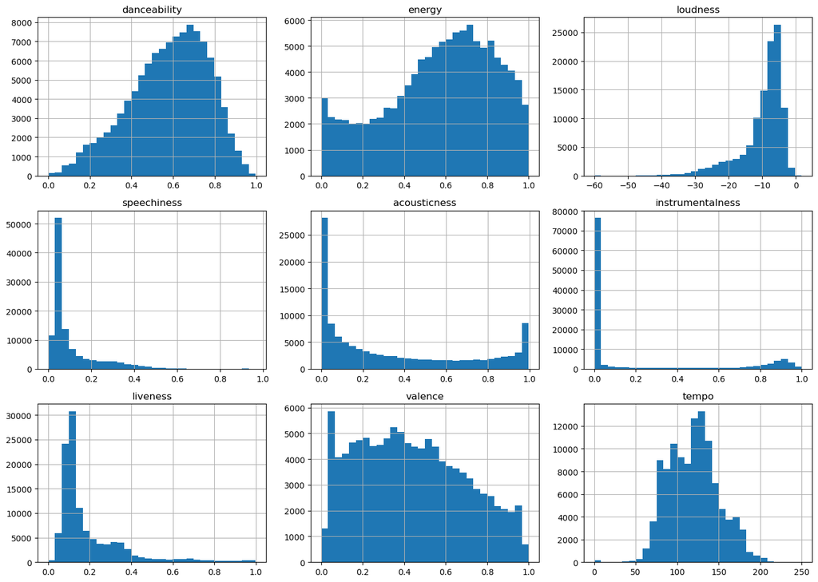

```python
X.hist(bins=30, figsize=(14,10))
plt.tight_layout()
plt.show()
```

### Results Interpretation

- You can clearly see distinct structural patterns:
  - Spikes at 0 (instrumentalness, speechiness)
  - Bimodal-like acousticness
  - Skewed distributions

This indicates clustering should be effective tool for data set

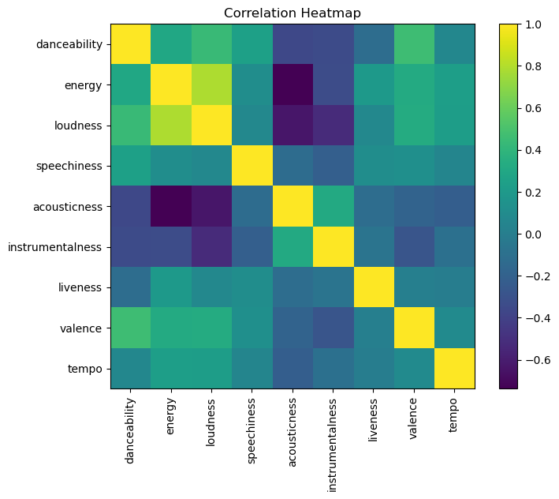

```python
corr = X.corr()
plt.figure(figsize=(8,6))
plt.imshow(corr)
plt.colorbar()
plt.xticks(range(len(corr)), corr.columns, rotation=90)
plt.yticks(range(len(corr)), corr.columns)
plt.title("Correlation Heatmap")
plt.show()
```

### Results Interpretation

- Strong positive relationship:
  - Energy ↔ Loudness (high correlation) → louder songs tend to be more energetic.
- Moderate positive cluster:
  - Danceability, energy, loudness, and valence are positively related → these likely define a “mainstream/high-energy” cluster.
- Strong negative relationships:
  - Acousticness vs energy/loudness → acoustic songs are typically quieter and less energetic.
- Instrumentalness patterns:
  - Positively related to acousticness and negatively to valence/energy → instrumental tracks tend to be calmer and less “happy/high-energy.”
- Weak correlations overall for some features:
  - Speechiness and liveness show weak relationships with most variables → they may form independent niche clusters.
- Tempo is relatively independent:
  - Weak correlations with most features → contributes unique variation in clustering.

```python
scaler = StandardScaler()
X_scaled = scaler.fit_transform(X)
```

### Results Interpretation

- Scaling the data so mean is 0 and sd is 1 for each variable and transforming data to fit that

## PCA and K-Means Clustering

```
Number of PCA components: 8
```

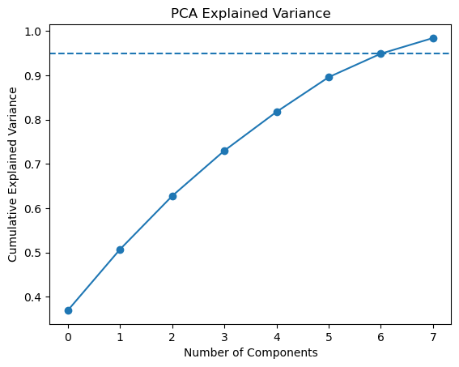

```python
pca = PCA(n_components=0.95, random_state=42)
X_pca = pca.fit_transform(X_scaled)

print("Number of PCA components:", pca.n_components_)

plt.plot(np.cumsum(pca.explained_variance_ratio_), marker='o')
plt.axhline(0.95, linestyle='--')
plt.xlabel("Number of Components")
plt.ylabel("Cumulative Explained Variance")
plt.title("PCA Explained Variance")
plt.show()
```

### Results Interpretation

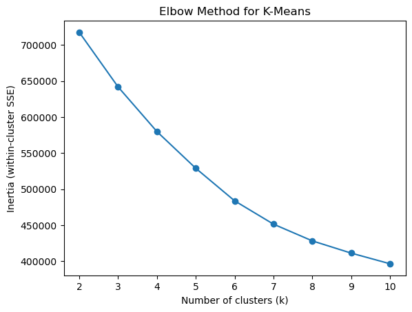

```python
inertias = []
k_values = range(2, 11)

for k in k_values:
    km = KMeans(n_clusters=k, random_state=42, n_init=10)
    km.fit(X_pca)
    inertias.append(km.inertia_)

plt.figure()
plt.plot(list(k_values), inertias, marker='o')
plt.xlabel("Number of clusters (k)")
plt.ylabel("Inertia (within-cluster SSE)")
plt.title("Elbow Method for K-Means")
plt.show()
```

### Results Interpretation

Chose k=5 as number of cluster do to drop in slop of curve after

```python
kmeans = KMeans(n_clusters=5, random_state=42)
clusters = kmeans.fit_predict(X_pca)

X_clustered = X.copy()
X_clustered['cluster'] = clusters
X_clustered.head()
```

|  | danceability | energy | loudness | speechiness | acousticness | instrumentalness | liveness | valence | tempo | cluster |
| --- | --- | --- | --- | --- | --- | --- | --- | --- | --- | --- |
| 0 | 0.743 | 0.339 | -7.678 | 0.4090 | 0.00582 | 0.00000 | 0.0812 | 0.118 | 203.927 | 1 |
| 1 | 0.603 | 0.723 | -5.890 | 0.0454 | 0.02500 | 0.00000 | 0.0824 | 0.382 | 114.966 | 0 |
| 2 | 0.821 | 0.512 | -7.138 | 0.0596 | 0.12500 | 0.00703 | 0.0879 | 0.543 | 128.035 | 0 |
| 3 | 0.574 | 0.881 | -2.150 | 0.1660 | 0.04480 | 0.00000 | 0.0756 | 0.551 | 126.131 | 0 |
| 4 | 0.699 | 0.309 | -10.790 | 0.1590 | 0.83200 | 0.17100 | 0.1160 | 0.422 | 79.991 | 2 |

```python
cluster_profile = X_clustered.groupby('cluster').mean()
cluster_profile
```

| cluster | danceability | energy | loudness | speechiness | acousticness | instrumentalness | liveness | valence | tempo |
| --- | --- | --- | --- | --- | --- | --- | --- | --- | --- |
| 0 | 0.703874 | 0.697552 | -6.447102 | 0.080316 | 0.178064 | 0.078683 | 0.147459 | 0.627364 | 120.092816 |
| 1 | 0.687764 | 0.609391 | -8.723502 | 0.367671 | 0.252945 | 0.034003 | 0.224571 | 0.499543 | 121.608312 |
| 2 | 0.553048 | 0.375028 | -11.147223 | 0.059423 | 0.633185 | 0.148796 | 0.151212 | 0.351107 | 113.468874 |
| 3 | 0.327700 | 0.152129 | -22.559329 | 0.051807 | 0.876724 | 0.741799 | 0.153204 | 0.212173 | 102.508236 |
| 4 | 0.490514 | 0.769782 | -6.833542 | 0.077170 | 0.082102 | 0.233690 | 0.311075 | 0.310167 | 132.624704 |

### Results Interpretation

- The clustering successfully identifies distinct music types, including high-energy tracks, speech-heavy songs, and acoustic or instrumental tracks, demonstrating meaningful structure in the dataset.

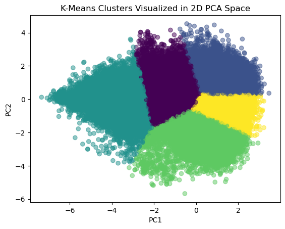

```python
from sklearn.decomposition import PCA

pca2 = PCA(n_components=2, random_state=42)
X_pca2 = pca2.fit_transform(X_scaled)

# Use your existing labels if you already clustered:
# labels = clusters

# Or refit KMeans for plotting (example uses k=5):
km = KMeans(n_clusters=5, random_state=42, n_init=10)
labels = km.fit_predict(X_pca2)

plt.figure()
plt.scatter(X_pca2[:, 0], X_pca2[:, 1], c=labels, alpha=0.5)
plt.xlabel("PC1")
plt.ylabel("PC2")
plt.title("K-Means Clusters Visualized in 2D PCA Space")
plt.show()
```

### Results Interpretation

```python
# Add cluster labels back to the original dataframe
df_clustered = df.loc[X.index].copy()
df_clustered['cluster'] = clusters

df_clustered[['danceability','energy','loudness', 'speechiness', 'acousticness', 'instrumentalness','liveness', 'valence','tempo','popularity','cluster']].head()
```

|  | danceability | energy | loudness | speechiness | acousticness | instrumentalness | liveness | valence | tempo | popularity | cluster |
| --- | --- | --- | --- | --- | --- | --- | --- | --- | --- | --- | --- |
| 0 | 0.743 | 0.339 | -7.678 | 0.4090 | 0.00582 | 0.00000 | 0.0812 | 0.118 | 203.927 | 15 | 1 |
| 1 | 0.603 | 0.723 | -5.890 | 0.0454 | 0.02500 | 0.00000 | 0.0824 | 0.382 | 114.966 | 56 | 0 |
| 2 | 0.821 | 0.512 | -7.138 | 0.0596 | 0.12500 | 0.00703 | 0.0879 | 0.543 | 128.035 | 28 | 0 |
| 3 | 0.574 | 0.881 | -2.150 | 0.1660 | 0.04480 | 0.00000 | 0.0756 | 0.551 | 126.131 | 29 | 0 |
| 4 | 0.699 | 0.309 | -10.790 | 0.1590 | 0.83200 | 0.17100 | 0.1160 | 0.422 | 79.991 | 31 | 2 |

### Results Interpretation

- K-means clustering reveals that mainstream, high-energy songs tend to be the most popular, while speech-heavy and acoustic tracks form distinct but less dominant listener segments.
- also decided to leave rows with 0 in the different columns as it is assumed that those songs simply didn't have those specific audio features

```python
df_clustered.groupby('cluster')['popularity'].mean()
```

```
cluster
0    31.743323
1    28.599777
2    28.901621
3    18.371623
4    28.376207
Name: popularity, dtype: float64
```

```python
cluster_profile = X_clustered.groupby('cluster').mean()

# Build a small table with popularity + cluster labels aligned by index
pop_by_song = df.loc[X_clustered.index, 'popularity'].copy()
pop_cluster_df = pd.DataFrame({
    'popularity': pop_by_song,
    'cluster': X_clustered['cluster']
})

avg_popularity = pop_cluster_df.groupby('cluster')['popularity'].mean()

cluster_profile['avg_popularity'] = avg_popularity
cluster_profile
```

| cluster | danceability | energy | loudness | speechiness | acousticness | instrumentalness | liveness | valence | tempo | avg_popularity |
| --- | --- | --- | --- | --- | --- | --- | --- | --- | --- | --- |
| 0 | 0.703874 | 0.697552 | -6.447102 | 0.080316 | 0.178064 | 0.078683 | 0.147459 | 0.627364 | 120.092816 | 31.743323 |
| 1 | 0.687764 | 0.609391 | -8.723502 | 0.367671 | 0.252945 | 0.034003 | 0.224571 | 0.499543 | 121.608312 | 28.599777 |
| 2 | 0.553048 | 0.375028 | -11.147223 | 0.059423 | 0.633185 | 0.148796 | 0.151212 | 0.351107 | 113.468874 | 28.901621 |
| 3 | 0.327700 | 0.152129 | -22.559329 | 0.051807 | 0.876724 | 0.741799 | 0.153204 | 0.212173 | 102.508236 | 18.371623 |
| 4 | 0.490514 | 0.769782 | -6.833542 | 0.077170 | 0.082102 | 0.233690 | 0.311075 | 0.310167 | 132.624704 | 28.376207 |

### Results Interpretation

- Most music types are around the same level of popularity except for type 3 that seems to be the the least popular by a large margin

## Hierarchical Clustering

### Hierarchical Clustering

Trying Hierarchical clustering as it builds clusters step-by-step instead of forcing all songs into groups at once like K-means. will show if song groups have a nested structure.

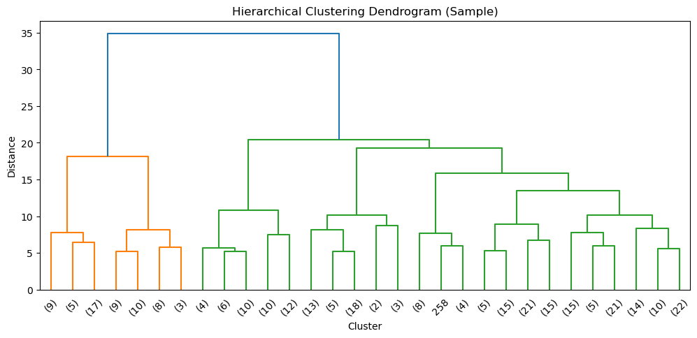

```python
# Dendrogram on a sample (kept smaller so it runs faster and stays readable)
dendro_size = min(300, len(X_pca))
rng = np.random.default_rng(42)
dendro_idx = rng.choice(len(X_pca), size=dendro_size, replace=False)
X_dendro = X_pca[dendro_idx]

linked = linkage(X_dendro, method='ward')

plt.figure(figsize=(12, 5))
dendrogram(linked, truncate_mode='lastp', p=30)
plt.title('Hierarchical Clustering Dendrogram (Sample)')
plt.xlabel('Cluster')
plt.ylabel('Distance')
plt.show()
```

### Results Interpretation

- Hierarchical clustering confirms that the dataset contains both large-scale divisions and smaller subgroups, reinforcing the validity of using multiple clusters (e.g., k = 5) for detailed segmentation.

```python
# Fit hierarchical clustering on the PCA-reduced data
n_clusters = 5
hier_sample_size = min(3000, len(X_pca))   # lower this if your machine still struggles
rng = np.random.default_rng(42)

if len(X_pca) > hier_sample_size:
    hier_idx = rng.choice(len(X_pca), size=hier_sample_size, replace=False)
    X_pca_hier = X_pca[hier_idx]
else:
    hier_idx = np.arange(len(X_pca))
    X_pca_hier = X_pca

agg = AgglomerativeClustering(n_clusters=n_clusters, linkage='ward')
agg_clusters = agg.fit_predict(X_pca_hier)

hier_clustered = X.iloc[hier_idx].copy()
hier_clustered['hier_cluster'] = agg_clusters

print("Hierarchical sample shape:", X_pca_hier.shape)
print("Number of hierarchical labels:", len(agg_clusters))
print("Hierarchical silhouette score:", round(silhouette_score(X_pca_hier, agg_clusters), 4))

hier_clustered.head()
```

```
Hierarchical sample shape: (3000, 8)
Number of hierarchical labels: 3000
Hierarchical silhouette score: 0.2049
```

|  | danceability | energy | loudness | speechiness | acousticness | instrumentalness | liveness | valence | tempo | hier_cluster |
| --- | --- | --- | --- | --- | --- | --- | --- | --- | --- | --- |
| 72066 | 0.608 | 0.603 | -6.095 | 0.1930 | 0.1530 | 0.000000 | 0.0685 | 0.117 | 92.135 | 0 |
| 47314 | 0.685 | 0.879 | -5.976 | 0.0514 | 0.0928 | 0.901000 | 0.0812 | 0.533 | 100.009 | 3 |
| 37818 | 0.773 | 0.651 | -8.133 | 0.2420 | 0.3800 | 0.000167 | 0.1240 | 0.507 | 119.957 | 0 |
| 32813 | 0.508 | 0.192 | -10.291 | 0.0520 | 0.8640 | 0.000000 | 0.0497 | 0.251 | 76.777 | 0 |
| 68646 | 0.778 | 0.574 | -9.183 | 0.0432 | 0.0311 | 0.000051 | 0.1000 | 0.305 | 123.043 | 0 |

### Results Interpretation

```python
# Profile hierarchical clusters
hier_profile = hier_clustered.groupby('hier_cluster').mean()
hier_profile['avg_popularity'] = df.loc[hier_clustered.index].groupby(hier_clustered['hier_cluster'])['popularity'].mean()
hier_profile
```

| hier_cluster | danceability | energy | loudness | speechiness | acousticness | instrumentalness | liveness | valence | tempo | avg_popularity |
| --- | --- | --- | --- | --- | --- | --- | --- | --- | --- | --- |
| 0 | 0.632698 | 0.650666 | -6.868407 | 0.080274 | 0.228058 | 0.019588 | 0.161965 | 0.481831 | 123.049716 | 32.349815 |
| 1 | 0.372131 | 0.194106 | -19.940042 | 0.050563 | 0.865837 | 0.602182 | 0.135749 | 0.246613 | 111.457622 | 20.747012 |
| 2 | 0.662617 | 0.614557 | -9.017840 | 0.367374 | 0.281089 | 0.033042 | 0.190061 | 0.526597 | 119.030035 | 27.614130 |
| 3 | 0.559373 | 0.684710 | -9.791126 | 0.069760 | 0.146701 | 0.773422 | 0.198807 | 0.375805 | 119.168701 | 23.479885 |
| 4 | 0.499029 | 0.635824 | -9.155884 | 0.138466 | 0.315469 | 0.096262 | 0.691363 | 0.476326 | 122.913220 | 25.908537 |

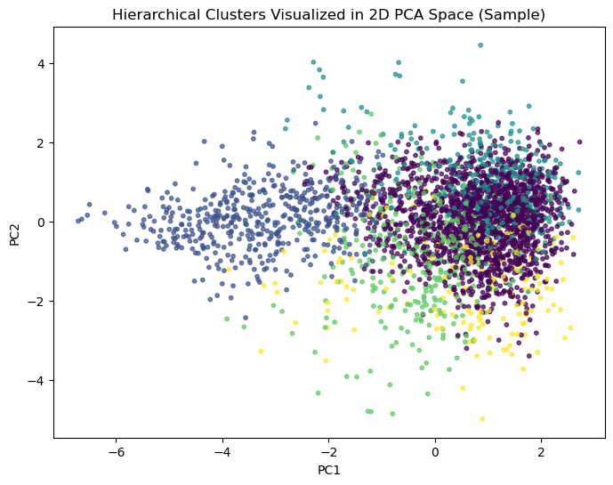

```python
# Visualize hierarchical clusters in 2D PCA space
plt.figure(figsize=(8, 6))
plt.scatter(
    X_pca_hier[:, 0],
    X_pca_hier[:, 1],
    c=agg_clusters,
    s=10,
    alpha=0.7
)
plt.xlabel('PC1')
plt.ylabel('PC2')
plt.title('Hierarchical Clusters Visualized in 2D PCA Space (Sample)')
plt.show()
```

### PyTorch Autoencoder

```python
# Prepare data for PyTorch
X_tensor = torch.tensor(X_scaled, dtype=torch.float32)
dataset = TensorDataset(X_tensor)
loader = DataLoader(dataset, batch_size=64, shuffle=True)

device = torch.device('cuda' if torch.cuda.is_available() else 'cpu')
print('Using device:', device)
```

```
Using device: cpu
```

### Insights

Preparing data for efficient trianing in PyTorch

```python
# Define the autoencoder
class Autoencoder(nn.Module):
    def __init__(self, input_dim, latent_dim=3):
        super().__init__()
        self.encoder = nn.Sequential(
            nn.Linear(input_dim, 16),
            nn.ReLU(),
            nn.Linear(16, 8),
            nn.ReLU(),
            nn.Linear(8, latent_dim)
        )
        self.decoder = nn.Sequential(
            nn.Linear(latent_dim, 8),
            nn.ReLU(),
            nn.Linear(8, 16),
            nn.ReLU(),
            nn.Linear(16, input_dim)
        )

    def forward(self, x):
        z = self.encoder(x)
        x_hat = self.decoder(z)
        return x_hat

input_dim = X_scaled.shape[1]
autoencoder = Autoencoder(input_dim=input_dim, latent_dim=3).to(device)
criterion = nn.MSELoss()
optimizer = torch.optim.Adam(autoencoder.parameters(), lr=0.001)
```

### Insights

- allows model to learn a compressed (nonlinear) representation of the data that preserves important structure for tasks like clustering

```python
# Train the autoencoder
num_epochs = 50
loss_history = []

autoencoder.train()
for epoch in range(num_epochs):
    epoch_loss = 0.0
    for batch in loader:
        xb = batch[0].to(device)

        optimizer.zero_grad()
        reconstructed = autoencoder(xb)
        loss = criterion(reconstructed, xb)
        loss.backward()
        optimizer.step()

        epoch_loss += loss.item() * xb.size(0)

    epoch_loss /= len(dataset)
    loss_history.append(epoch_loss)

    if (epoch + 1) % 10 == 0:
        print(f'Epoch {epoch+1}/{num_epochs}, Loss: {epoch_loss:.6f}')
```

[output not shown]

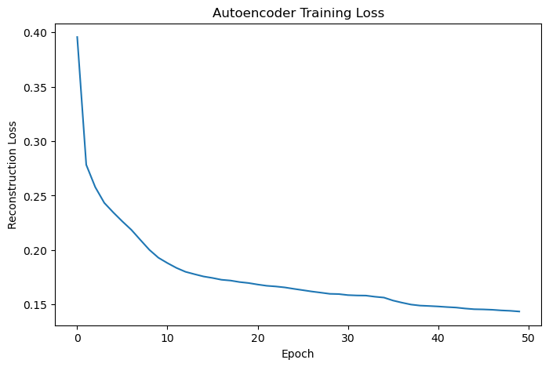

```python
# Plot training loss
plt.figure(figsize=(8,5))
plt.plot(loss_history)
plt.xlabel('Epoch')
plt.ylabel('Reconstruction Loss')
plt.title('Autoencoder Training Loss')
plt.show()
```

### Results Interpretation

- The steadily decreasing and stabilizing loss indicates that the autoencoder effectively captures the underlying structure of the data and converges to a good representation.w.

```python
# Extract latent features
autoencoder.eval()
with torch.no_grad():
    latent_features = autoencoder.encoder(X_tensor.to(device)).cpu().numpy()

print('Latent feature shape:', latent_features.shape)
latent_features[:5]
```

```
Latent feature shape: (111774, 3)
```

```
array([[ 0.27407408,  2.0556788 , -1.0150644 ],
       [-0.28846514,  2.219563  ,  0.25386658],
       [-0.5360116 ,  2.2638865 ,  0.23017207],
       [ 0.30494547,  2.2457123 ,  0.11195603],
       [-0.69999254,  3.4120374 ,  0.27571908]], dtype=float32)
```

### Results Interpretation

```python
# Cluster the latent features learned by the autoencoder
ae_kmeans = KMeans(n_clusters=n_clusters, random_state=42, n_init=10)
ae_clusters = ae_kmeans.fit_predict(latent_features)

ae_clustered = X.copy()
ae_clustered['ae_cluster'] = ae_clusters
ae_clustered.head()
```

|  | danceability | energy | loudness | speechiness | acousticness | instrumentalness | liveness | valence | tempo | ae_cluster |
| --- | --- | --- | --- | --- | --- | --- | --- | --- | --- | --- |
| 0 | 0.743 | 0.339 | -7.678 | 0.4090 | 0.00582 | 0.00000 | 0.0812 | 0.118 | 203.927 | 1 |
| 1 | 0.603 | 0.723 | -5.890 | 0.0454 | 0.02500 | 0.00000 | 0.0824 | 0.382 | 114.966 | 1 |
| 2 | 0.821 | 0.512 | -7.138 | 0.0596 | 0.12500 | 0.00703 | 0.0879 | 0.543 | 128.035 | 1 |
| 3 | 0.574 | 0.881 | -2.150 | 0.1660 | 0.04480 | 0.00000 | 0.0756 | 0.551 | 126.131 | 1 |
| 4 | 0.699 | 0.309 | -10.790 | 0.1590 | 0.83200 | 0.17100 | 0.1160 | 0.422 | 79.991 | 3 |

```python
# Profile autoencoder-based clusters
ae_profile = ae_clustered.groupby('ae_cluster').mean()
ae_profile['avg_popularity'] = df.loc[ae_clustered.index].groupby(ae_clustered['ae_cluster'])['popularity'].mean()
ae_profile
```

| ae_cluster | danceability | energy | loudness | speechiness | acousticness | instrumentalness | liveness | valence | tempo | avg_popularity |
| --- | --- | --- | --- | --- | --- | --- | --- | --- | --- | --- |
| 0 | 0.681784 | 0.603374 | -9.145494 | 0.358956 | 0.275515 | 0.021814 | 0.251210 | 0.521356 | 108.873568 | 28.163199 |
| 1 | 0.652274 | 0.666114 | -6.641775 | 0.100952 | 0.174260 | 0.017399 | 0.134826 | 0.446482 | 125.264062 | 32.388211 |
| 2 | 0.549742 | 0.710969 | -7.801059 | 0.066130 | 0.139030 | 0.495118 | 0.155163 | 0.434163 | 142.882379 | 26.646882 |
| 3 | 0.441404 | 0.233020 | -17.468326 | 0.053506 | 0.818728 | 0.447166 | 0.125664 | 0.315639 | 104.695162 | 23.338835 |
| 4 | 0.559748 | 0.695245 | -8.093952 | 0.073149 | 0.270070 | 0.129663 | 0.446578 | 0.528714 | 113.167928 | 28.117828 |

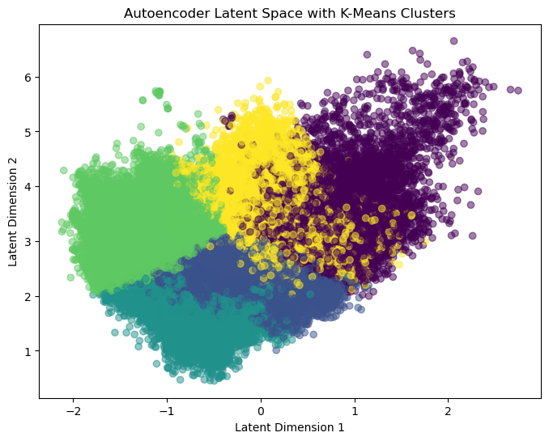

```python
# Visualize autoencoder latent space
plt.figure(figsize=(8,6))
plt.scatter(latent_features[:, 0], latent_features[:, 1], c=ae_clusters, alpha=0.5)
plt.xlabel('Latent Dimension 1')
plt.ylabel('Latent Dimension 2')
plt.title('Autoencoder Latent Space with K-Means Clusters')
plt.show()
```

### Results Interpretation

- The autoencoder-based clustering produces the most distinct and interpretable clusters by capturing nonlinear relationships in the data, leading to improved separation and clearer identification of music styles compared to both PCA-based and hierarchical approaches.

### Compare Clustering Models

Below is comparing the original K-means approach, hierarchical clustering, and the deep learning approach (autoencoder + K-means). Higher silhouette and Calinski-Harabasz values are better, while lower Davies-Bouldin values are better.

```python
# KMeans on full PCA
kmeans_sil = silhouette_score(X_pca, clusters)
kmeans_ch  = calinski_harabasz_score(X_pca, clusters)
kmeans_db  = davies_bouldin_score(X_pca, clusters)

# Hierarchical on sampled PCA only
hier_sil = silhouette_score(X_pca_hier, agg_clusters)
hier_ch  = calinski_harabasz_score(X_pca_hier, agg_clusters)
hier_db  = davies_bouldin_score(X_pca_hier, agg_clusters)

# Autoencoder + KMeans on full latent features
ae_sil = silhouette_score(latent_features, ae_clusters)
ae_ch  = calinski_harabasz_score(latent_features, ae_clusters)
ae_db  = davies_bouldin_score(latent_features, ae_clusters)

# Compare clustering methods using internal validation metrics
comparison = pd.DataFrame({
    "Model": [
        "KMeans on PCA",
        "Hierarchical on PCA sample",
        "Autoencoder + KMeans"
    ],
    "Silhouette Score": [kmeans_sil, hier_sil, ae_sil],
    "Calinski-Harabasz Score": [kmeans_ch, hier_ch, ae_ch],
    "Davies-Bouldin Score": [kmeans_db, hier_db, ae_db]
})

comparison.sort_values(by="Silhouette Score", ascending=False)
```

|  | Model | Silhouette Score | Calinski-Harabasz Score | Davies-Bouldin Score |
| --- | --- | --- | --- | --- |
| 2 | Autoencoder + KMeans | 0.290370 | 46519.718750 | 1.103419 |
| 1 | Hierarchical on PCA sample | 0.204853 | 537.974506 | 1.646953 |
| 0 | KMeans on PCA | 0.168790 | 24130.109974 | 1.706862 |

### Results Interpretation

- Best Overall Model → Autoencoder + KMeans
  - Highest Silhouette: 0.290 → best separation
  - Highest CH score: 46,519 → strongest cluster structure
  - Lowest DB score: 1.103 → least overlap This model clearly produces the most distinct, compact, and well-separated clusters
- Middle Performance → Hierarchical (PCA Sample)
  - Silhouette: 0.205 → moderate separation
  - CH score: ~538 → very low cluster compactness
  - DB score: 1.647 → noticeable overlap Captures some structure but clusters are weak and less defined
- Weakest Model → KMeans on PCA
  - Lowest Silhouette: 0.169 → poor separation
  - CH score: 24,130 (moderate but misleading without silhouette)
  - Highest DB: 1.707 → most overlap Clusters are least distinct, even after dimensionality reduction

## Takeaways

- Autoencoder significantly improves clustering
  - captures nonlinear relationships that PCA cannot
- Hierarchical clustering underperforms
  - struggles with overlapping music features
- PCA + KMeans loses important structure
  - linear reduction removes useful information